# GR 5073 Midterm

## Yi YIN

### 1.

Import the spam dataset and print the first six rows.

```python
import pandas as pd
import numpy as np
import matplotlib.pyplot as plt
import seaborn as sns

import statsmodels.api as sm
import pylab as pl


%matplotlib inline

pd.options.display.max_rows = 10

# Import the spam dataset
data= pd.read_csv("./spam_dataset.csv")

# print the first six rows
data[0:6]
```

|  | word_freq_make: | word_freq_address: | word_freq_all: | word_freq_3d: | word_freq_our: | word_freq_over: | word_freq_remove: | word_freq_internet: | word_freq_order: | word_freq_mail: | ... | char_freq_;: | char_freq_(: | char_freq_[: | char_freq_!: | char_freq_$: | char_freq_#: | capital_run_length_average: | capital_run_length_longest: | capital_run_length_total: | spam |
| --- | --- | --- | --- | --- | --- | --- | --- | --- | --- | --- | --- | --- | --- | --- | --- | --- | --- | --- | --- | --- | --- |
| 0 | 0.00 | 0.64 | 0.64 | 0.0 | 0.32 | 0.00 | 0.00 | 0.00 | 0.00 | 0.00 | ... | 0.00 | 0.000 | 0.0 | 0.778 | 0.000 | 0.000 | 3.756 | 61 | 278 | 1 |
| 1 | 0.21 | 0.28 | 0.50 | 0.0 | 0.14 | 0.28 | 0.21 | 0.07 | 0.00 | 0.94 | ... | 0.00 | 0.132 | 0.0 | 0.372 | 0.180 | 0.048 | 5.114 | 101 | 1028 | 1 |
| 2 | 0.06 | 0.00 | 0.71 | 0.0 | 1.23 | 0.19 | 0.19 | 0.12 | 0.64 | 0.25 | ... | 0.01 | 0.143 | 0.0 | 0.276 | 0.184 | 0.010 | 9.821 | 485 | 2259 | 1 |
| 3 | 0.00 | 0.00 | 0.00 | 0.0 | 0.63 | 0.00 | 0.31 | 0.63 | 0.31 | 0.63 | ... | 0.00 | 0.137 | 0.0 | 0.137 | 0.000 | 0.000 | 3.537 | 40 | 191 | 1 |
| 4 | 0.00 | 0.00 | 0.00 | 0.0 | 0.63 | 0.00 | 0.31 | 0.63 | 0.31 | 0.63 | ... | 0.00 | 0.135 | 0.0 | 0.135 | 0.000 | 0.000 | 3.537 | 40 | 191 | 1 |
| 5 | 0.00 | 0.00 | 0.00 | 0.0 | 1.85 | 0.00 | 0.00 | 1.85 | 0.00 | 0.00 | ... | 0.00 | 0.223 | 0.0 | 0.000 | 0.000 | 0.000 | 3.000 | 15 | 54 | 1 |

6 rows × 58 columns

### 2.

Read through the documentation of the original dataset

The dependent variable is "spam" where one indicates that an email is spam and zero otherwise. Which three variables in the dataset do you think will be important predictors in a model of spam? Why?*

I think `word_freq_order:`,`char_freq_$:` and `capital_run_length_total:` would be important predictors in a model of spam. Because commercial marketing emails usually promote their products with the information of price (using $), phrases like "order now!", and using capitialized phrases to catch attention.

### 3.

Visualize the univariate distribution of each of the variables in the previous question.

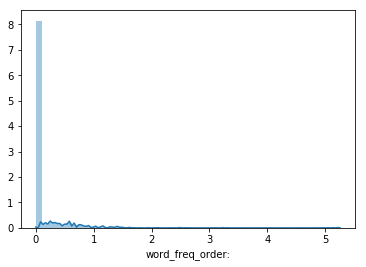

```python
sns.distplot(data['word_freq_order:'])
```

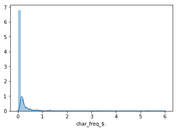

```python
sns.distplot(data['char_freq_$:'])
```

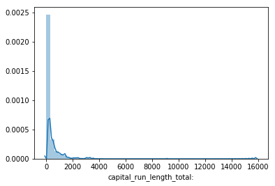

```python
sns.distplot(data['capital_run_length_total:'])
```

### 4.

Drawing from the *full spam dataset*, name each of the supervised learning models that we have learned thus far that are used to predict dependent variables like "spam".

```python
y = data['spam']
X = data.loc[:, data.columns != 'spam']

## Scaling data
from sklearn.preprocessing import StandardScaler
Xss = StandardScaler()
X_s = Xss.fit_transform(X)
X_s = pd.DataFrame(X_s,columns=X.columns)
```

### a) KNN

```python
from sklearn.neighbors import KNeighborsClassifier

# initialize model
knn = KNeighborsClassifier(n_neighbors=5)
knn.fit(X_s, y)

# predictions
knn_pred = knn.predict(X_s)
```

```python
# classification_report matrix

from sklearn.metrics import confusion_matrix, classification_report

display(pd.DataFrame(
    confusion_matrix(y, knn_pred),
    columns=['Predicted Ham', 'Predicted Spam'],
    index=['True Ham', 'True Spam']
))

print(classification_report(y, knn_pred))

# percent of correct prediction
print("overall accuracy: {:.5f}".format(knn.score(X_s, y)))
```

|  | Predicted Ham | Predicted Spam |
| --- | --- | --- |
| True Ham | 2655 | 133 |
| True Spam | 159 | 1654 |

```
             precision    recall  f1-score   support

          0       0.94      0.95      0.95      2788
          1       0.93      0.91      0.92      1813

avg / total       0.94      0.94      0.94      4601

overall accuracy: 0.93654
```

### b) (Penalized) Logistic regression

```python
from sklearn.linear_model import LogisticRegression

# initialize model
lr = LogisticRegression(C=1e9)
lr.fit(X_s,y)

# predictions
lr_pred = lr.predict(X_s)
```

```python
from sklearn.metrics import confusion_matrix, classification_report

display(pd.DataFrame(
    confusion_matrix(y, lr_pred),
    columns=['Predicted Ham', 'Predicted Spam'],
    index=['True Ham', 'True Spam']
))

# classification_report matrix
print(classification_report(y, lr_pred))


# percent of correct prediction
print("overall accuracy: {:.5f}".format(lr.score(X_s, y)))
```

|  | Predicted Ham | Predicted Spam |
| --- | --- | --- |
| True Ham | 2667 | 121 |
| True Spam | 195 | 1618 |

```
             precision    recall  f1-score   support

          0       0.93      0.96      0.94      2788
          1       0.93      0.89      0.91      1813

avg / total       0.93      0.93      0.93      4601

overall accuracy: 0.93132
```

**(Penalized)**

```python
# initialize model
plr = LogisticRegression(C=1)
plr.fit(X_s, y)

# predictions
plr_pred = plr.predict(X_s)
```

```python
from sklearn.metrics import confusion_matrix, classification_report

display(pd.DataFrame(
    confusion_matrix(y, plr_pred),
    columns=['Predicted Ham', 'Predicted Spam'],
    index=['True Ham', 'True Spam']
))

# classification_report matrix
print(classification_report(y, plr_pred))


# percent of correct prediction
print("overall accuracy: {:.5f}".format(plr.score(X_s, y)))
```

|  | Predicted Ham | Predicted Spam |
| --- | --- | --- |
| True Ham | 2666 | 122 |
| True Spam | 199 | 1614 |

```
             precision    recall  f1-score   support

          0       0.93      0.96      0.94      2788
          1       0.93      0.89      0.91      1813

avg / total       0.93      0.93      0.93      4601

overall accuracy: 0.93023
```

### c) SVM

```python
from sklearn.svm import SVC

# simple SVM: linear kernel
svm = SVC(kernel='linear')
svm.fit(X_s, y)

svm_pred = svm.predict(X_s)
```

```python
from sklearn.metrics import confusion_matrix, classification_report

display(pd.DataFrame(
    confusion_matrix(y, svm_pred),
    columns=['Predicted Ham', 'Predicted Spam'],
    index=['True Ham', 'True Spam']
))

print(classification_report(y, svm_pred))

print("overall accuracy: {:.5f}".format(svm.score(X_s, y)))
```

|  | Predicted Ham | Predicted Spam |
| --- | --- | --- |
| True Ham | 2663 | 125 |
| True Spam | 185 | 1628 |

```
             precision    recall  f1-score   support

          0       0.94      0.96      0.94      2788
          1       0.93      0.90      0.91      1813

avg / total       0.93      0.93      0.93      4601

overall accuracy: 0.93262
```

```python
## Gaussian Kernel
gsvm = SVC(kernel='rbf')
gsvm.fit(X_s, y)

gsvm_pred = gsvm.predict(X_s)
```

```python
from sklearn.metrics import confusion_matrix, classification_report

display(pd.DataFrame(
    confusion_matrix(y, gsvm_pred),
    columns=['Predicted Ham', 'Predicted Spam'],
    index=['True Ham', 'True Spam']
))

print(classification_report(y, gsvm_pred))

print("overall accuracy: {:.5f}".format(gsvm.score(X_s, y)))
```

|  | Predicted Ham | Predicted Spam |
| --- | --- | --- |
| True Ham | 2697 | 91 |
| True Spam | 151 | 1662 |

```
             precision    recall  f1-score   support

          0       0.95      0.97      0.96      2788
          1       0.95      0.92      0.93      1813

avg / total       0.95      0.95      0.95      4601

overall accuracy: 0.94740
```

### d) Decision Tree

```python
from sklearn.tree import DecisionTreeClassifier

tree = DecisionTreeClassifier()
tree.fit(X_s,y)

tree_pred = tree.predict(X_s)
```

```python
from sklearn.metrics import confusion_matrix, classification_report

display(pd.DataFrame(
    confusion_matrix(y, tree_pred),
    columns=['Predicted Ham', 'Predicted Spam'],
    index=['True Ham', 'True Spam']
))

print(classification_report(y, tree_pred))

print("overall accuracy: {:.5f}".format(tree.score(X_s, y)))
```

|  | Predicted Ham | Predicted Spam |
| --- | --- | --- |
| True Ham | 2788 | 0 |
| True Spam | 3 | 1810 |

```
             precision    recall  f1-score   support

          0       1.00      1.00      1.00      2788
          1       1.00      1.00      1.00      1813

avg / total       1.00      1.00      1.00      4601

overall accuracy: 0.99935
```

### e) Random Forest

```python
from sklearn.ensemble import RandomForestClassifier

rf = RandomForestClassifier()

rf.fit(X_s,y)

rf_pred = rf.predict(X_s)
```

```python
from sklearn.metrics import confusion_matrix, classification_report

display(pd.DataFrame(
    confusion_matrix(y, rf_pred),
    columns=['Predicted Ham', 'Predicted Spam'],
    index=['True Ham', 'True Spam']
))

print(classification_report(y, rf_pred))

print("overall accuracy: {:.5f}".format(rf.score(X_s, y)))
```

|  | Predicted Ham | Predicted Spam |
| --- | --- | --- |
| True Ham | 2785 | 3 |
| True Spam | 27 | 1786 |

```
             precision    recall  f1-score   support

          0       0.99      1.00      0.99      2788
          1       1.00      0.99      0.99      1813

avg / total       0.99      0.99      0.99      4601

overall accuracy: 0.99348
```

### f) Bagging

```python
from sklearn.tree import DecisionTreeClassifier
from sklearn.ensemble import BaggingClassifier

tree = DecisionTreeClassifier()
bag = BaggingClassifier(tree)

bag.fit(X_s,y)

bag_pred = bag.predict(X_s)
```

```python
from sklearn.metrics import confusion_matrix, classification_report

display(pd.DataFrame(
    confusion_matrix(y, bag_pred),
    columns=['Predicted Ham', 'Predicted Spam'],
    index=['True Ham', 'True Spam']
))

print(classification_report(y, bag_pred))

print("overall accuracy: {:.5f}".format(bag.score(X_s, y)))
```

|  | Predicted Ham | Predicted Spam |
| --- | --- | --- |
| True Ham | 2786 | 2 |
| True Spam | 15 | 1798 |

```
             precision    recall  f1-score   support

          0       0.99      1.00      1.00      2788
          1       1.00      0.99      1.00      1813

avg / total       1.00      1.00      1.00      4601

overall accuracy: 0.99631
```

### 5.

Describe the importance of training and test data. Why do we separate data into these subsets?

Because out goal is to build a model to make accurate predictions on new data with the same features as the data we have seen. Without the partition of training and test subsets, we tend to build models overfit the current dataset, but hard to generalize to new data.

The evaluation of a model is based on how well it perferm on new data. Without new data, we split current data into two subsets: training and test, and use to test dataset to evaluate our model performance.

### 6.

What is k-fold cross validation and what do we use it for?

K-fold cross validation is to split the dataset into k parts of equal size, called folds; and a series of models are trained by using one fold as test data. And then we gain k accuracy values, and take the mean of those values. Compared to a single split into test and training, K-fold cross validation gives us more stable evaluation of generalization perfermance since each example will be in the training dataset once, the model need to generalize well to all the samples in a dataset to get a high mean of cross-validation scores. And k-fold cross validation help use to make use of our data more effectively since we gain more information than a single split.

### 7.

How is k-fold cross validation different from stratified k-fold cross validation?

K-fold cross validation only split the data into k folds. Stratified K-fold cross validation split the data to ensure the proportions between classes are the same in each fold, which provide more reliable estimates of generalization performance for evaluating classfication models.

### 8.

Choose one model from question four. -- **KNN**

Split the data into training and test subsets. Build a model with the three variables in the dataset that you think will be good predictors of "spam".

```python
y = data['spam']
X = data[['word_freq_order:','char_freq_$:', 'capital_run_length_total:']]
```

```python
# Training test split
from sklearn.model_selection import train_test_split
X_train, X_test, y_train, y_test = train_test_split(X, y, random_state=0)
X_train.info()
```

```
<class 'pandas.core.frame.DataFrame'>
Int64Index: 3450 entries, 118 to 2732
Data columns (total 3 columns):
word_freq_order:             3450 non-null float64
char_freq_$:                 3450 non-null float64
capital_run_length_total:    3450 non-null int64
dtypes: float64(2), int64(1)
memory usage: 107.8 KB
```

```python
from sklearn import preprocessing
## Scaling data
scaler = preprocessing.StandardScaler()
scaler.fit(X_train)
X_train_s = scaler.transform(X_train)

scaler.fit(X_test)
X_test_s = scaler.transform(X_test)
```

Describe why you chose any particular parameters for your model (e.g.- if you used KNN how did you decide to choose a specific value for k).

I use `GridSeachCV` to find that k=17 has the best cross validation socre.

```python
## GridSearchCV to find the best tuning parameter
from sklearn.model_selection import GridSearchCV
from sklearn.neighbors import KNeighborsClassifier

param_grid = {'n_neighbors': np.arange(1, 21, 2)}

grid = GridSearchCV(KNeighborsClassifier(), param_grid=param_grid, cv=10)

grid.fit(X_train_s, y_train)

print("best mean cross-validation score: {:.5f}".format(grid.best_score_))
print("best parameters: {}".format(grid.best_params_))
```

```
best mean cross-validation score: 0.78319
best parameters: {'n_neighbors': 17}
```

Run the model and evaluate prediction error in two ways. A) On test data directly and B) using k-fold cross-validation.

```python
# A) on the test data

knn = KNeighborsClassifier(n_neighbors=17)
knn.fit(X_train_s, y_train)

print("Test set score: {:.5f}".format(knn.score(X_test_s, y_test)))
```

```
Test set score: 0.77585
```

```python
# B) using k-fold cross-validation.
from sklearn.model_selection import KFold, cross_val_score

k_fold = KFold(n_splits=10)

print("Average cross-validation score: {:.5f}".format(np.mean(cross_val_score(KNeighborsClassifier(n_neighbors=17),
                                                                              X_train_s,
                                                                              y_train,
                                                                              cv= k_fold))))
```

```
Average cross-validation score: 0.78493
```

### 9.

Choose a second model from question four. -- **Penalized Logistic Regression**

Using the same three variables in the dataset that you think will be good predictors of "spam". Describe why you chose any particular parameters for your model (e.g.- if you used KNN how did you decide to choose a specific value for k).

I use `GridSeachCV` to find that c=100 has the best cross validation socre.

```python
## GridSearchCV to find the best tuning parameter
from sklearn.linear_model import LogisticRegression

para_lg = {'C': [0.001, 0.01, 0.1, 1, 10, 100, 1000] }

gs_lg = GridSearchCV(LogisticRegression(), param_grid=para_lg, cv=10)

lggrid = gs_lg.fit(X_train_s, y_train)

print("best mean cross-validation score: {:.5f}".format(lggrid.best_score_))
print("best parameters: {}".format(lggrid.best_params_))
```

```
best mean cross-validation score: 0.77565
best parameters: {'C': 100}
```

```python
# A) on the test data

logreg = LogisticRegression(C=100)

logreg.fit(X_train_s, y_train)

print("Test set score: {:.5f}".format(logreg.score(X_test_s, y_test)))
```

```
Test set score: 0.77237
```

Run the model and evaluate prediction error in two ways. A) On test data directly and B) using k-fold cross-validation.

```python
# B) using k-fold cross-validation.
from sklearn.model_selection import KFold, cross_val_score

k_fold = KFold(n_splits=10)

print("Average cross-validation score: {:.5f}".format(np.mean(cross_val_score(LogisticRegression(C=100),
                                                                              X_train_s,
                                                                              y_train,
                                                                              cv= k_fold))))
```

```
Average cross-validation score: 0.77478
```

**Did this model predict test data better than your previous models?**

No

### 10.

Choose a third model from question four. -- **SVM**

Using the same three variables in the dataset that you think will be good predictors of "spam". Describe why you chose any particular parameters for your model (e.g.- if you used KNN how did you decide to choose a specific value for k).

I use `GridSeachCV` to find that kernel = 'rbf'; C=10; gamma = 1 has the best cross validation socre.

```python
from sklearn import svm, grid_search

Cs = [0.001, 0.01, 0.1, 1, 10]
gammas = [0.001, 0.01, 0.1, 1]
kernels = ['linear','rbf']


param_svm = {'C': Cs, 'gamma' : gammas, 'kernel': kernels}

grid_svm = GridSearchCV(svm.SVC(), param_grid = param_svm, cv=10)

svmgrid = grid_svm.fit(X_train_s, y_train)

print("best mean cross-validation score: {:.5f}".format(svmgrid.best_score_))

print("best parameters: {}".format(svmgrid.best_params_))
```

```
best mean cross-validation score: 0.80000
best parameters: {'C': 10, 'gamma': 1, 'kernel': 'rbf'}
```

Run the model and evaluate prediction error in two ways. A) On test data directly and B) using k-fold cross-validation. Did this model predict test data better than your previous models?

```python
# A) on the test data

bestsvm = svm.SVC(kernel='rbf', C = 10, gamma= 1)

bestsvm.fit(X_train_s, y_train)

print("Test set score: {:.5f}".format(bestsvm.score(X_test_s, y_test)))
```

```
Test set score: 0.79235
```

```python
# B) using k-fold cross-validation.
from sklearn.model_selection import KFold, cross_val_score

k_fold = KFold(n_splits=10)

print("Average cross-validation score: {:.5f}".format(np.mean(cross_val_score(svm.SVC(kernel='rbf', C = 10, gamma= 1),
                                                                              X_train_s,
                                                                              y_train,
                                                                              cv= k_fold))))
```

```
Average cross-validation score: 0.80029
```

**Did this model predict test data better than your previous models?**

-- Yes, both in terms of test data and k-fold cross validation show the improvement.

### 11.

Choose a fourth model from question four. --**Decision Tree**

Using the same three variables in the dataset that you think will be good predictors of "spam". Describe why you chose any particular parameters for your model (e.g.- if you used KNN how did you decide to choose a specific value for k).

I use `GridSeachCV` to find that criterion = entropy; max_depth = 6; min_samples_leaf= 2 has the best cross validation socre.

```python
from sklearn.model_selection import GridSearchCV
from sklearn.tree import DecisionTreeClassifier

tree = DecisionTreeClassifier()
#Hyper Parameters Set
params_tree = {'max_depth': np.arange(1, 21),
          'criterion': ['gini','entropy'],
          'min_samples_leaf':np.arange(1, 21)}

grid_tree = GridSearchCV(DecisionTreeClassifier(), param_grid = params_tree, cv=10)

treegrid = grid_tree.fit(X_train_s, y_train)

print("best mean cross-validation score: {:.5f}".format(treegrid.best_score_))

print("best parameters: {}".format(treegrid.best_params_))
```

```
best mean cross-validation score: 0.79855
best parameters: {'criterion': 'entropy', 'max_depth': 6, 'min_samples_leaf': 2}
```

Run the model and evaluate prediction error in two ways. A) On test data directly and B) using k-fold cross-validation. Did this model predict test data better than your previous models?

```python
# A) on the test data

bestress = DecisionTreeClassifier(criterion = 'entropy', max_depth = 6, min_samples_leaf= 2)

bestress.fit(X_train_s, y_train)

print("Test set score: {:.5f}".format(bestress.score(X_test_s, y_test)))
```

```
Test set score: 0.79670
```

```python
# B) using k-fold cross-validation.
from sklearn.model_selection import KFold, cross_val_score

k_fold = KFold(n_splits=10)

print("Average cross-validation score: {:.5f}".format(np.mean(cross_val_score(bestress,
                                                                              X_train_s,
                                                                              y_train,
                                                                              cv= k_fold))))
```

```
Average cross-validation score: 0.79565
```

### 12.

Now rerun your best model from questions 8 through 11, but this time add three new variables to the model that you think will increase prediction accuracy.

```python
y = data['spam']
X_3 = data[['word_freq_order:','char_freq_$:', 'capital_run_length_total:',
          'word_freq_free:', 'capital_run_length_average:', 'char_freq_!:']]

# Training test split
from sklearn.model_selection import train_test_split
X_train_3, X_test_3, y_train_3, y_test_3 = train_test_split(X_3, y, random_state=0)
X_train_3.info()

from sklearn import preprocessing
## Scaling data
scaler = preprocessing.StandardScaler()
scaler.fit(X_train_3)
X_train_3s = scaler.transform(X_train_3)

scaler.fit(X_test_3)
X_test_3s = scaler.transform(X_test_3)
```

```
<class 'pandas.core.frame.DataFrame'>
Int64Index: 3450 entries, 118 to 2732
Data columns (total 6 columns):
word_freq_order:               3450 non-null float64
char_freq_$:                   3450 non-null float64
capital_run_length_total:      3450 non-null int64
word_freq_free:                3450 non-null float64
capital_run_length_average:    3450 non-null float64
char_freq_!:                   3450 non-null float64
dtypes: float64(5), int64(1)
memory usage: 188.7 KB
```

```python
bestsvm = svm.SVC(kernel='rbf', C = 10, gamma= 1)

bestsvm.fit(X_train_3s, y_train_3)

# A) on test data
print("Test set score: {:.5f}".format(bestsvm.score(X_test_3s, y_test_3)))

# B) using k-fold cross-validation.
from sklearn.model_selection import KFold, cross_val_score

k_fold = KFold(n_splits=10)

print("Average cross-validation score: {:.5f}".format(np.mean(cross_val_score(bestsvm,
                                                                              X_train_3s,
                                                                              y_train_3,
                                                                              cv= k_fold))))
```

```
Test set score: 0.87142
Average cross-validation score: 0.88290
```

**Did this model predict test data better than your previous models?**

-- Yes, the model predict better with 3 more features

### 13.

Rerun all your other models with this final set of six variables, evaluate prediction error, and choose a final model. Why did you select this model among all of the models that you ran?

**-- With 3 more features, every model get improvement. The SVM model still has the best performance on test data and 10 fold validation score. So I select SVM model**

```python
# Decision Tree
bestress = DecisionTreeClassifier(criterion = 'entropy', max_depth = 6, min_samples_leaf= 2)
bestress.fit(X_train_3s, y_train_3)

# A) on test data
print("Test set score: {:.5f}".format(bestress.score(X_test_3s, y_test_3)))

# B) using k-fold cross-validation.
from sklearn.model_selection import KFold, cross_val_score

k_fold = KFold(n_splits=10)

print("Average cross-validation score: {:.5f}".format(np.mean(cross_val_score(bestress,
                                                                              X_train_3s,
                                                                              y_train_3,
                                                                              cv= k_fold))))
```

```
Test set score: 0.85317
Average cross-validation score: 0.87710
```

```python
# Penalized Logistic Regression
logreg = LogisticRegression(C=100)

logreg.fit(X_train_3s, y_train_3)

# A) on test data
print("Test set score: {:.5f}".format(logreg.score(X_test_3s, y_test_3)))

# B) using k-fold cross-validation.
from sklearn.model_selection import KFold, cross_val_score

k_fold = KFold(n_splits=10)

print("Average cross-validation score: {:.5f}".format(np.mean(cross_val_score(logreg,
                                                                              X_train_3s,
                                                                              y_train_3,
                                                                              cv= k_fold))))
```

```
Test set score: 0.84448
Average cross-validation score: 0.83536
```

```python
# KNN

knn = KNeighborsClassifier(n_neighbors=17)
knn.fit(X_train_3s, y_train_3)

# A) on test data
print("Test set score: {:.5f}".format(knn.score(X_test_3s, y_test_3)))

# B) using k-fold cross-validation.
from sklearn.model_selection import KFold, cross_val_score

k_fold = KFold(n_splits=10)

print("Average cross-validation score: {:.5f}".format(np.mean(cross_val_score(knn,
                                                                              X_train_3s,
                                                                              y_train_3,
                                                                              cv= k_fold))))
```

```
Test set score: 0.85925
Average cross-validation score: 0.86783
```

### 14.

What variable that currently is not in your model, if included, would be likely to increase your final model's predictive power?

**-- 'word_freq_receive:', 'word_freq_credit:', 'capital_run_length_longest:'**

```python
y = data['spam']
X_6 = data[['word_freq_order:','char_freq_$:', 'capital_run_length_total:',
          'word_freq_free:', 'capital_run_length_average:', 'char_freq_!:',
           'word_freq_receive:', 'word_freq_credit:', 'capital_run_length_longest:']]

# Training test split
from sklearn.model_selection import train_test_split
X_train_6, X_test_6, y_train_6, y_test_6 = train_test_split(X_6, y, random_state=0)

from sklearn import preprocessing
## Scaling data
scaler = preprocessing.StandardScaler()
scaler.fit(X_train_6)
X_train_6s = scaler.transform(X_train_6)

scaler.fit(X_test_6)
X_test_6s = scaler.transform(X_test_6)
```

```python
bestsvm = svm.SVC(kernel='rbf', C = 10, gamma= 1)

bestsvm.fit(X_train_6s, y_train_6)

# A) on test data
print("Test set score: {:.5f}".format(bestsvm.score(X_test_6s, y_test_6)))

# B) using k-fold cross-validation.
from sklearn.model_selection import KFold, cross_val_score

k_fold = KFold(n_splits=10)

print("Average cross-validation score: {:.5f}".format(np.mean(cross_val_score(bestsvm,
                                                                              X_train_6s,
                                                                              y_train_6,
                                                                              cv= k_fold))))
```

```
Test set score: 0.86099
Average cross-validation score: 0.88696
```

### 15.

Lastly, you have listed each of the models that we have learned to use to predict dependent variables like spam. List each model we have focused on in class thus far that you could use to evaluate data with a continuous dependent variable.

- KNN for regression
- OLS regression
- Ridge regression
- Lasso regression
- Decision Tree regression
- Random Forest regression
- Bagging regression